# DL2DWH Lab

In this lab you are asked to cover the following points:

1. Data ingestion
2. Data understanding
3. Design and build a relational DWH
4. Query the DWH with Tableau (Desktop)
5. (Bonus) Plot the provenance graph

```python
!pip install awswrangler
!pip install pandas
!pip install sklearn
!pip install prov
!pip install seaborn
!pip install pydot
!pip install graphviz
import warnings
warnings.filterwarnings('ignore')
```

```python
import pandas as pd
import awswrangler as wr
import seaborn as sns
import prov
```

## Data ingestion

- Upload the following files in S3 (remember the naming conventions of the data lake areas!)
  - http://big.csr.unibo.it/projects/nosql-datasets/sales_fact_1997.slice-0-1.v0.0.1.csv
  - http://big.csr.unibo.it/projects/nosql-datasets/sales_fact_1997.slice-1-2.v0.0.1.csv
  - http://big.csr.unibo.it/projects/nosql-datasets/sales_fact_1997.slice-2-3.v0.0.1.csv
- Merge/Append them into a single Pandas DataFrame
  - Which is the underlying assumption so that `append` works?
  - See https://pandas.pydata.org/docs/reference/api/pandas.DataFrame.append.html
- Save the processed dataset into S3

```python
landing_bucket = "s3://lab-landing-raw-sales-123/"
staging_bucket = "s3://lab-staging-clean-sales-123/"

file_name1 = "sales_fact_1997.slice-0-1.v0.0.1.csv"
filename2 = "sales_fact_1997.slice-1-2.v0.0.1.csv"
filename3 = "sales_fact_1997.slice-2-3.v0.0.1.csv"

# Import all the data from the s3 lake in different dataframes
df1 = pd.read_csv("http://big.csr.unibo.it/projects/nosql-datasets/" + file_name1)
df2 = pd.read_csv("http://big.csr.unibo.it/projects/nosql-datasets/" + filename2)
df3 = df = pd.read_csv("http://big.csr.unibo.it/projects/nosql-datasets/" + filename3)

# Merging or appending the data into one big file
first = df1.append(df2, ignore_index=True)
second = first.append(df3, ignore_index=True)
df_merged = second
# wr.s3.to_csv(df, path=input_bucket + file_name)
```

```python
# look at the top 5
df_merged.head(5)
```

|  | C. City | C. Country | C. State | Customer | Yearly Income | Category | Subcategory | Family | Product | S. City | S. Country | S. State | Store | Type | Sales Date | Store Cost | Store Sales | Unit Sales |
| --- | --- | --- | --- | --- | --- | --- | --- | --- | --- | --- | --- | --- | --- | --- | --- | --- | --- | --- |
| 0 | Albany | USA | OR | 117 | $90K - $110K | Baking Goods | Cooking Oil | Food | Super Corn Oil | Salem | USA | OR | 13 | Deluxe Supermarket | 1/21/1997 12:00:00 AM | 2.1177 | 5.43 | 3 |
| 1 | Albany | USA | OR | 117 | $90K - $110K | Baking Goods | Sauces | Food | Landslide Tomato Sauce | Salem | USA | OR | 13 | Deluxe Supermarket | 1/21/1997 12:00:00 AM | 1.6500 | 5.00 | 4 |
| 2 | Albany | USA | OR | 117 | $90K - $110K | Baking Goods | Sugar | Food | Landslide Brown Sugar | Salem | USA | OR | 13 | Deluxe Supermarket | 1/21/1997 12:00:00 AM | 5.3760 | 11.20 | 4 |
| 3 | Albany | USA | OR | 117 | $90K - $110K | Bathroom Products | Conditioner | Non-Consumable | Consolidated Silky Smooth Hair Conditioner | Salem | USA | OR | 13 | Deluxe Supermarket | 1/21/1997 12:00:00 AM | 1.1466 | 2.94 | 2 |
| 4 | Albany | USA | OR | 117 | $90K - $110K | Beer and Wine | Wine | Drink | Pearl Merlot Wine | Salem | USA | OR | 13 | Deluxe Supermarket | 1/21/1997 12:00:00 AM | 0.9288 | 2.16 | 4 |

```python
# dimension of the data
df_merged.shape
```

```
(86829, 18)
```

## Data understanding

- What is the dataset about?
- Which are candidate levels/measures?
- Check and fix the missing values (if any)
- How many products have been sold?
  - See https://pandas.pydata.org/docs/reference/api/pandas.Series.value_counts.html
- Which functional dependencies hold among the levels?
  - Given a relation R, a set of attributes X in R is said to functionally determine another set of attributes Y, also in R, (written X → Y) if, and only if, each X value is associated with precisely one Y value; R is then said to satisfy the functional dependency X → Y.
  - See https://pandas.pydata.org/docs/reference/api/pandas.DataFrame.nunique.html
  - Hint: `df.groupby([...])` + `nunique()`
- Are there relationships between measures?
  - See https://seaborn.pydata.org/generated/seaborn.pairplot.html
  - See https://pandas.pydata.org/pandas-docs/stable/reference/api/pandas.DataFrame.corr.html

```python
# TODO
```

```python
# getting an insight about the data
df_merged.info()
```

```
<class 'pandas.core.frame.DataFrame'>
RangeIndex: 86829 entries, 0 to 86828
Data columns (total 18 columns):
 #   Column         Non-Null Count  Dtype
---  ------         --------------  -----
 0   C. City        86829 non-null  object
 1   C. Country     86829 non-null  object
 2   C. State       86829 non-null  object
 3   Customer       86829 non-null  int64
 4   Yearly Income  86829 non-null  object
 5   Category       86829 non-null  object
 6   Subcategory    86829 non-null  object
 7   Family         86829 non-null  object
 8   Product        86829 non-null  object
 9   S. City        86829 non-null  object
 10  S. Country     86829 non-null  object
 11  S. State       86829 non-null  object
 12  Store          86829 non-null  int64
 13  Type           86829 non-null  object
 14  Sales Date     86829 non-null  object
 15  Store Cost     86829 non-null  float64
 16  Store Sales    86829 non-null  float64
 17  Unit Sales     86829 non-null  int64
dtypes: float64(2), int64(3), object(13)
memory usage: 11.9+ MB
```

```python
# Run a simple statistics on the data
df_merged.describe().transpose()
```

|  | count | mean | std | min | 25% | 50% | 75% | max |
| --- | --- | --- | --- | --- | --- | --- | --- | --- |
| Customer | 86829.0 | 5137.738451 | 2906.854365 | 3.000 | 2632.000 | 5092.0000 | 7639.0000 | 10277.000 |
| Store | 86829.0 | 13.165256 | 6.207908 | 2.000 | 7.000 | 13.0000 | 17.0000 | 24.000 |
| Store Cost | 86829.0 | 2.598186 | 1.447287 | 0.153 | 1.479 | 2.3684 | 3.4716 | 9.875 |
| Store Sales | 86829.0 | 6.508941 | 3.465830 | 0.500 | 3.780 | 5.9200 | 8.6400 | 23.640 |
| Unit Sales | 86829.0 | 3.072050 | 0.847164 | 1.000 | 3.000 | 3.0000 | 4.0000 | 6.000 |

```python
# Checking for missing values
df_merged.isnull()
```

|  | C. City | C. Country | C. State | Customer | Yearly Income | Category | Subcategory | Family | Product | S. City | S. Country | S. State | Store | Type | Sales Date | Store Cost | Store Sales | Unit Sales |
| --- | --- | --- | --- | --- | --- | --- | --- | --- | --- | --- | --- | --- | --- | --- | --- | --- | --- | --- |
| 0 | False | False | False | False | False | False | False | False | False | False | False | False | False | False | False | False | False | False |
| 1 | False | False | False | False | False | False | False | False | False | False | False | False | False | False | False | False | False | False |
| 2 | False | False | False | False | False | False | False | False | False | False | False | False | False | False | False | False | False | False |
| 3 | False | False | False | False | False | False | False | False | False | False | False | False | False | False | False | False | False | False |
| 4 | False | False | False | False | False | False | False | False | False | False | False | False | False | False | False | False | False | False |
| ... | ... | ... | ... | ... | ... | ... | ... | ... | ... | ... | ... | ... | ... | ... | ... | ... | ... | ... |
| 86824 | False | False | False | False | False | False | False | False | False | False | False | False | False | False | False | False | False | False |
| 86825 | False | False | False | False | False | False | False | False | False | False | False | False | False | False | False | False | False | False |
| 86826 | False | False | False | False | False | False | False | False | False | False | False | False | False | False | False | False | False | False |
| 86827 | False | False | False | False | False | False | False | False | False | False | False | False | False | False | False | False | False | False |
| 86828 | False | False | False | False | False | False | False | False | False | False | False | False | False | False | False | False | False | False |

86829 rows × 18 columns

```python
#sum total missing values if any
df_merged.isna().sum()
```

```
C. City          0
C. Country       0
C. State         0
Customer         0
Yearly Income    0
Category         0
Subcategory      0
Family           0
Product          0
S. City          0
S. Country       0
S. State         0
Store            0
Type             0
Sales Date       0
Store Cost       0
Store Sales      0
Unit Sales       0
dtype: int64
```

```python
# columns in the dataset
df_merged.columns
```

```
Index(['C. City', 'C. Country', 'C. State', 'Customer', 'Yearly Income',
       'Category', 'Subcategory', 'Family', 'Product', 'S. City', 'S. Country',
       'S. State', 'Store', 'Type', 'Sales Date', 'Store Cost', 'Store Sales',
       'Unit Sales'],
      dtype='object')
```

```python
# total sale units
df_merged[['Unit Sales']].sum()
```

```
Unit Sales    266743
dtype: int64
```

```python
# number of unique products
df_merged[["Product"]].nunique()
```

```
Product    1559
dtype: int64
```

```python
df_merged.nunique()
```

```
C. City             78
C. Country           1
C. State             3
Customer          5581
Yearly Income        8
Category            45
Subcategory        102
Family               3
Product           1559
S. City             13
S. Country           1
S. State             3
Store               13
Type                 5
Sales Date         323
Store Cost       10776
Store Sales       1049
Unit Sales           6
dtype: int64
```

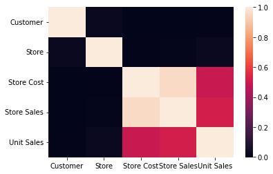

```python
# importing seaborn and visualization correlation in the data
import seaborn as sns
sns.heatmap(df_merged.corr())
```

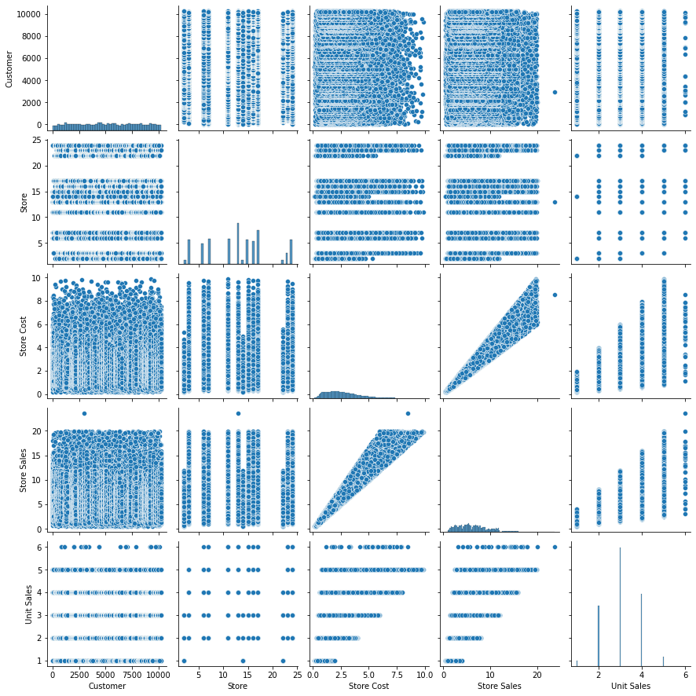

```python
# visualizing pairplot
sns.pairplot(df_merged)
```

## Which functional dependencies hold among the levels

To be seen with TABLEAU

```python
# finally write the data back to s3
wr.s3.to_csv(df=df_merged, path= staging_bucket + "df_merged_clean" , index=False)
```

```
{'paths': ['s3://lab-staging-clean-sales-123/df_merged_clean'],
 'partitions_values': {}}
```

```python
# write database catalog
databases = wr.catalog.databases()
databases
```

|  | Database | Description |
| --- | --- | --- |

```python
# write the tables
df_tables = wr.catalog.tables()
df_tables
```

|  | Database | Table | Description | TableType | Columns | Partitions |
| --- | --- | --- | --- | --- | --- | --- |

## Design and build a relational DWH

- Create the database on Amazon RDS
- Design the relational schema of the DWH (which are the functional dependencies?)
- Upload the tables into rhw DWH

```python
# Read the data from the aws s3 staginb bucket area
raw_data = wr.s3.read_csv(staging_bucket + "df_merged_clean")
raw_data
```

|  | C. City | C. Country | C. State | Customer | Yearly Income | Category | Subcategory | Family | Product | S. City | S. Country | S. State | Store | Type | Sales Date | Store Cost | Store Sales | Unit Sales |
| --- | --- | --- | --- | --- | --- | --- | --- | --- | --- | --- | --- | --- | --- | --- | --- | --- | --- | --- |
| 0 | Albany | USA | OR | 117 | $90K - $110K | Baking Goods | Cooking Oil | Food | Super Corn Oil | Salem | USA | OR | 13 | Deluxe Supermarket | 1/21/1997 12:00:00 AM | 2.1177 | 5.43 | 3 |
| 1 | Albany | USA | OR | 117 | $90K - $110K | Baking Goods | Sauces | Food | Landslide Tomato Sauce | Salem | USA | OR | 13 | Deluxe Supermarket | 1/21/1997 12:00:00 AM | 1.6500 | 5.00 | 4 |
| 2 | Albany | USA | OR | 117 | $90K - $110K | Baking Goods | Sugar | Food | Landslide Brown Sugar | Salem | USA | OR | 13 | Deluxe Supermarket | 1/21/1997 12:00:00 AM | 5.3760 | 11.20 | 4 |
| 3 | Albany | USA | OR | 117 | $90K - $110K | Bathroom Products | Conditioner | Non-Consumable | Consolidated Silky Smooth Hair Conditioner | Salem | USA | OR | 13 | Deluxe Supermarket | 1/21/1997 12:00:00 AM | 1.1466 | 2.94 | 2 |
| 4 | Albany | USA | OR | 117 | $90K - $110K | Beer and Wine | Wine | Drink | Pearl Merlot Wine | Salem | USA | OR | 13 | Deluxe Supermarket | 1/21/1997 12:00:00 AM | 0.9288 | 2.16 | 4 |
| ... | ... | ... | ... | ... | ... | ... | ... | ... | ... | ... | ... | ... | ... | ... | ... | ... | ... | ... |
| 86824 | Yakima | USA | WA | 10226 | $10K - $30K | Jams and Jellies | Peanut Butter | Food | Plato Chunky Peanut Butter | Yakima | USA | WA | 23 | Mid-Size Grocery | 6/30/1997 12:00:00 AM | 1.9600 | 4.90 | 2 |
| 86825 | Yakima | USA | WA | 10226 | $10K - $30K | Meat | Hot Dogs | Food | Cutting Edge Chicken Hot Dogs | Yakima | USA | WA | 23 | Mid-Size Grocery | 6/30/1997 12:00:00 AM | 1.4229 | 4.59 | 3 |
| 86826 | Yakima | USA | WA | 10226 | $10K - $30K | Pizza | Pizza | Food | PigTail Frozen Pepperoni Pizza | Yakima | USA | WA | 23 | Mid-Size Grocery | 3/1/1997 12:00:00 AM | 1.0752 | 3.36 | 2 |
| 86827 | Yakima | USA | WA | 10226 | $10K - $30K | Vegetables | Fresh Vegetables | Food | Ebony Garlic | Yakima | USA | WA | 23 | Mid-Size Grocery | 2/11/1997 12:00:00 AM | 4.3680 | 10.40 | 4 |
| 86828 | Yakima | USA | WA | 10226 | $10K - $30K | Vegetables | Fresh Vegetables | Food | Hermanos Green Pepper | Yakima | USA | WA | 23 | Mid-Size Grocery | 2/11/1997 12:00:00 AM | 6.0216 | 15.44 | 4 |

86829 rows × 18 columns

## Connect tableau and aws

```python
host = "labbigdata.cbj7jwrd78zb.us-east-1.rds.amazonaws.com"
port = 5432
user = "postgres"
pwd = "Bigdata2022"
db = "postgres"

from sqlalchemy import create_engine
s = 'postgresql://{}:{}@{}:{}/{}'.format(user, pwd, host, str(port), db)
engine = create_engine(s)

# TODO
```

## Doing some ETL , modelling dependencies and populating the database on Aws RDS

### Modelling the hierachies in tableau

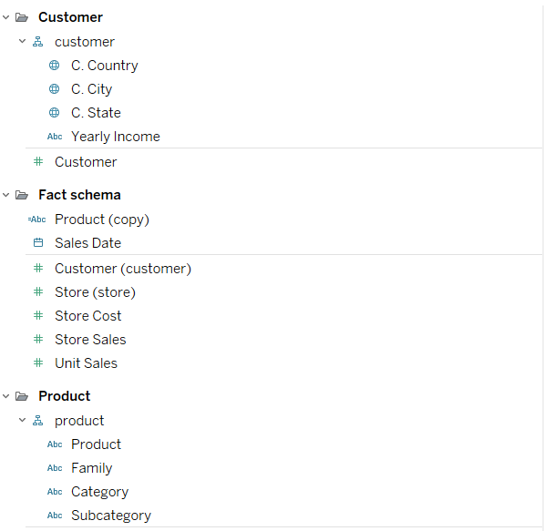

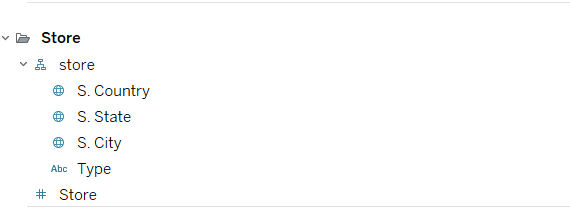

### Writing and populating the tables in the databases

```python
# DT_customer
df[['C. City', 'C. Country', 'C. State', 'Customer', 'Yearly Income']]\
  .drop_duplicates()\
  .to_sql('customer', engine, index=False, if_exists="replace")
```

```python
# DT_store
df[['S. City', 'S. Country','S. State', 'Store', 'Type']]\
  .drop_duplicates()\
  .to_sql('store', engine, index=False, if_exists="replace")
```

```python
# DT_product
df[['Category', 'Subcategory', 'Family', 'Product']]\
  .drop_duplicates()\
  .to_sql('product', engine, index=False, if_exists="replace")
```

```python
# DT_date
df[['Sales Date']]\
  .drop_duplicates()\
  .to_sql('date', engine, index=False, if_exists="replace")
```

```python
# FT
df[['Customer', 'Store', 'Product', 'Sales Date', 'Store Sales', 'Store Cost','Unit Sales']]\
  .drop_duplicates()\
  .to_sql('sales', engine, index=False, if_exists="replace")
```

## Query the DWH with Tableau (Desktop)

- Import data from Amazon RDS into Tableau
- Join the tables
- Set `Sales Date` as a Datetime attribute both in the fact and dimension tables
- Build the dimensions and hierarchies in Tableau
- Complete the following exercises

[figure not shown]

## Exercise 1

1. Using a bar chart, display the `sum` of `Store Sales` for each `S. State`
   - Which state has the highest sales?

Sum of Store Sales for each S.state:

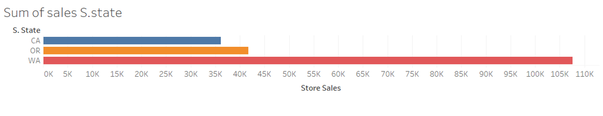

**Answer:** WA has the highest sales.

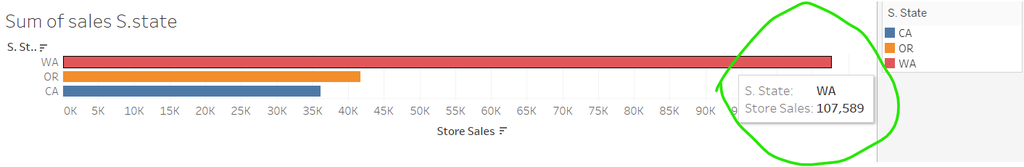

1. Drill down to view sales at the `S. City` level.
   - Are there cities with much lower sales than others?

   **Answer**: Yes there are sotres with lower sales

   ```
              Bellingham, Seattle, San Francisco, Walla Walla
   ```

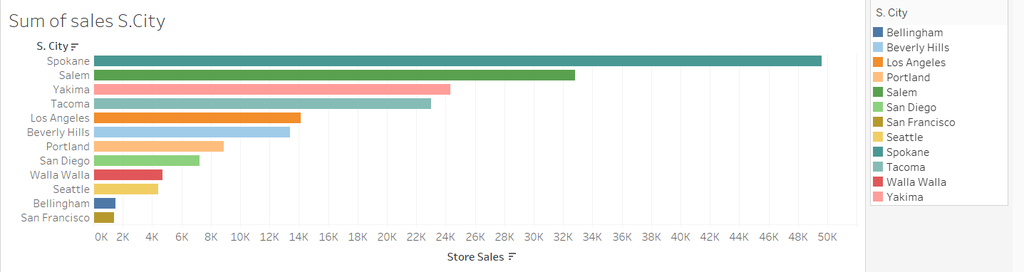

1. How many stores (`Stores`) are there in each `S. State`? What about in each `S. City`?
   - Tip: Use `COUNTD` aggregation. Why?

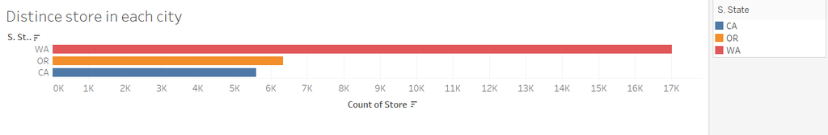

**Answer**: One distinct store in each city.

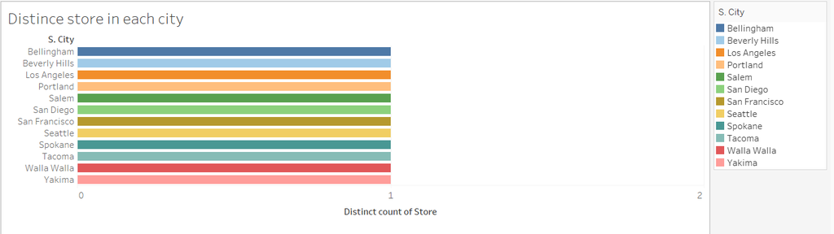

1. Can low sales in some cities be imputed to the number of stores?
   - Display sales at the `S. City` level (as done above) and associate the color property with the number of distinct stores (`COUNTD(store)`)

**Answer:** The answer is No, there's no direct correlation between number of store and sales.

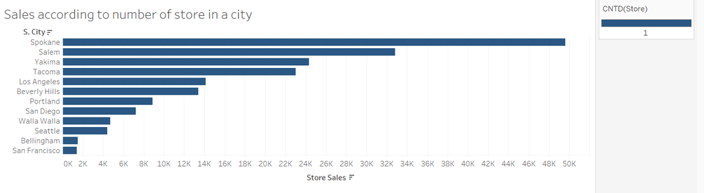

### Exercise 2

1. Given the last visualization, associate the `S. Type` field with the color property.
   - What interesting pattern can you see?

   **Answer:**

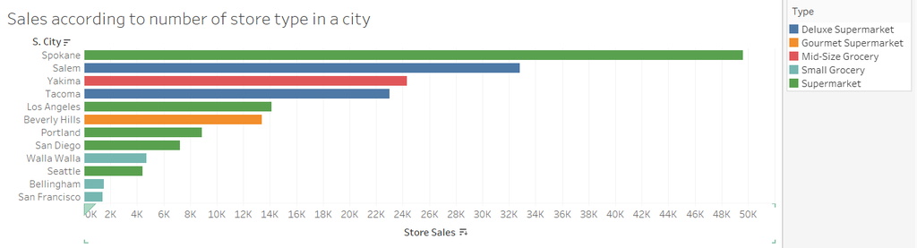

1. Display the sales (`SUM`) for each `S. Type`.
   - What discrepancy is possible to notice with respect to the previous chart?

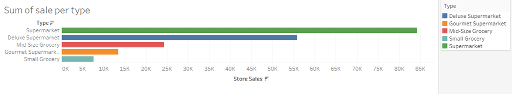

1. Associate the number of stores (`Store`) with the color property and the label property
   - What caused the discrepancy between the previous two visualizations?

[figure not shown]

### Exercise 3

1. Using a line chart, visualize the monthly sales trend
   - What pattern is present?

   **Answer:** Monthly sales trend seem to be normal with few huge sales in month and the highest accumulated sales in December.

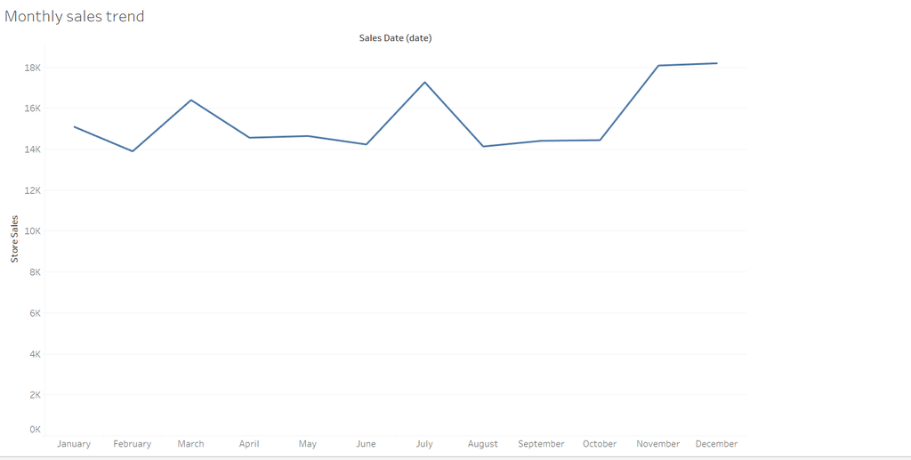

1. Divide the previous chart by `S. State` (one axis for each state)

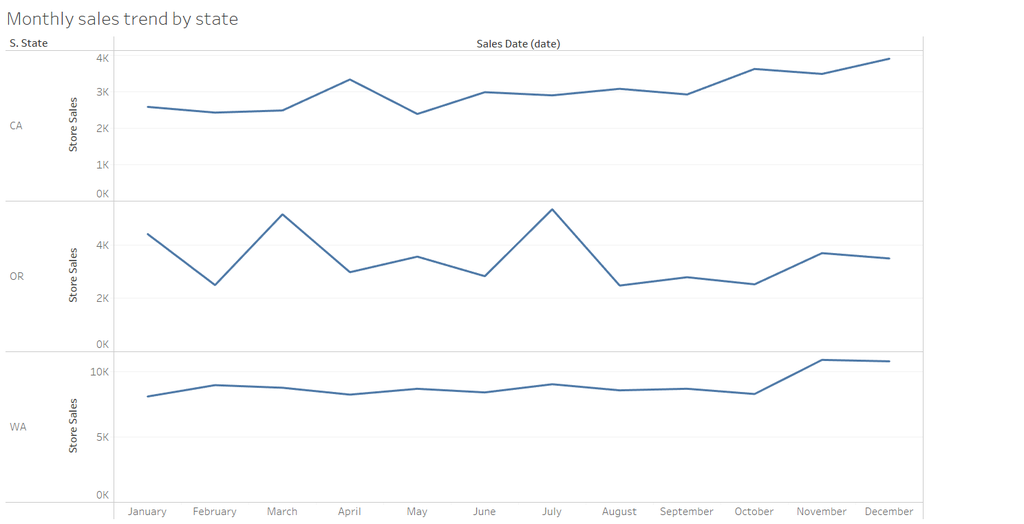

   - Is the previous pattern present in each `State`?
   - Tip: by default the axes all have the same range: on any axis, right-click > `Edit Axis` > `Select Independent axis...`
1. Given the previous chart, visualize how much impact the various `Family`s have on total sales while maintaining the monthly trend visualization
   - What might be a good visualization?
   - Tip: associate each Family with a mark property and possibly change the mark type
   - Tip: you can change the mark type from the drop-down menu in the mark panel

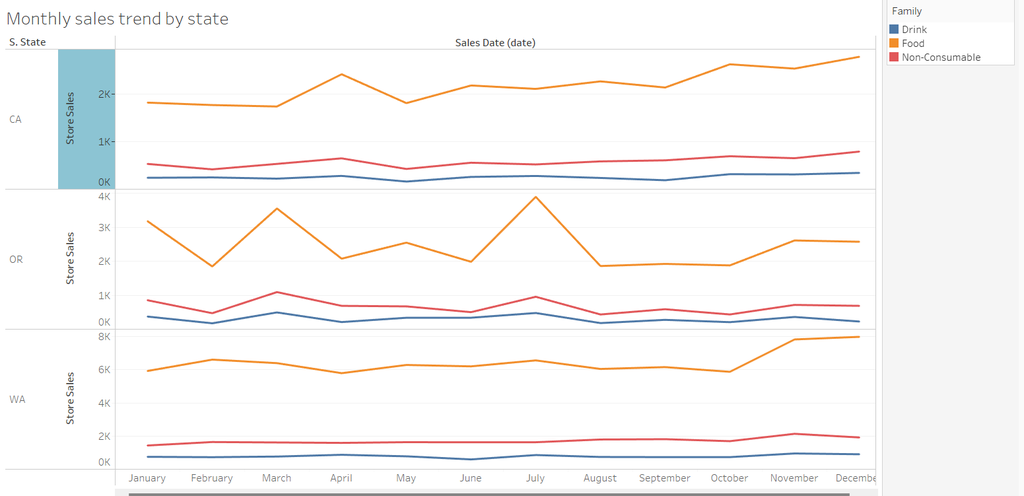

[figure not shown]

## (Bonus) Plot the provenance graph

- Plot the provenance graph representing the previous transformations using the PROV standard

```python
from prov.model import ProvDocument
from prov.dot import prov_to_dot
from IPython.display import Image

def plot():
    # Create a new provenance document
    d1 = ProvDocument()  # d1 is now an empty provenance document

    d1.add_namespace('s3', 'https://s3.console.aws.amazon.com/s3')
    d1.add_namespace('rds', 'https://us-east-1.console.aws.amazon.com/rds')
    d1.add_namespace('unibo', 'https://www.unibo.it')
    d1.add_namespace('pd', 'https://pandas.pydata.org/')

    # TODO

    # visualize the graph
    dot = prov_to_dot(d1)
    dot.write_png('prov.png')
    return Image('prov.png')
```

```python
plot()
```

[output not shown]